# Reproducible Research - Week 2 Course Project

Mark Zhang

June 23, 2018

#### *Introduction*

It is now possible to collect a large amount of data about personal movement using activity monitoring devices such as a Fitbit, Nike Fuelband, or Jawbone Up. These type of devices are part of the “quantified self” movement - a group of enthusiasts who take measurements about themselves regularly to improve their health, to find patterns in their behavior, or because they are tech geeks. But these data remain under-utilized both because the raw data are hard to obtain and there is a lack of statistical methods and software for processing and interpreting the data.

This assignment makes use of data from a personal activity monitoring device. This device collects data at 5 minute intervals through out the day. The data consists of two months of data from an anonymous individual collected during the months of October and November, 2012 and include the number of steps taken in 5 minute intervals each day.

The data for this assignment can be downloaded from the course web site:

Dataset: [Activity monitoring data[52K]](https://d396qusza40orc.cloudfront.net/repdata%2Fdata%2Factivity.zip)

Variables included in this dataset are:

- steps: Number of steps taking in a 5-minute interval (missing values are coded as NA)
- date: The date on which the measurement was taken in YYYY-MM-DD format
- interval: Identifier for the 5-minute interval in which measurement was taken

Below are some exploratory analysis and code that does the plotting/analysis.

#### *Reading and processing data*

```r
require(ggplot2)
require(dplyr)
activity <- tbl_df(read.csv('activity.csv', sep = ','))
```

#### *What is mean total number of steps taken per day?*

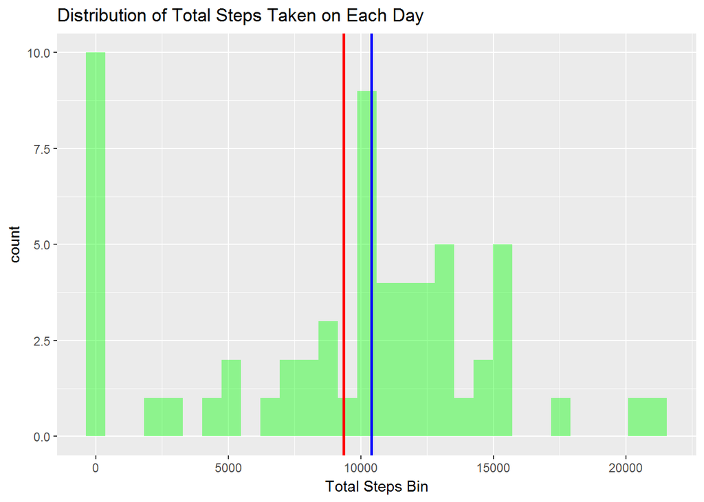

```r
actiGrouped <- group_by(activity, date) %>%
    summarise(totalsteps = sum(steps, na.rm = T))

meanSteps <- mean(actiGrouped$totalsteps, na.rm = T)
medianSteps <- median(actiGrouped$totalsteps, na.rm = T)

ggplot(actiGrouped, aes(actiGrouped$totalsteps)) +
    geom_histogram(fill = 'green',
                   alpha = 0.4) +
    labs(title = 'Distribution of Total Steps Taken on Each Day') +
    labs(x = 'Total Steps Bin') +
    geom_vline(xintercept = mean(actiGrouped$totalsteps, na.rm = T),
               color = 'red',
               lwd = 1) +
    geom_vline(xintercept = median(actiGrouped$totalsteps, na.rm = T),
               color = 'blue',
               lwd = 1)
```

#### *What is the average daily activity pattern?*

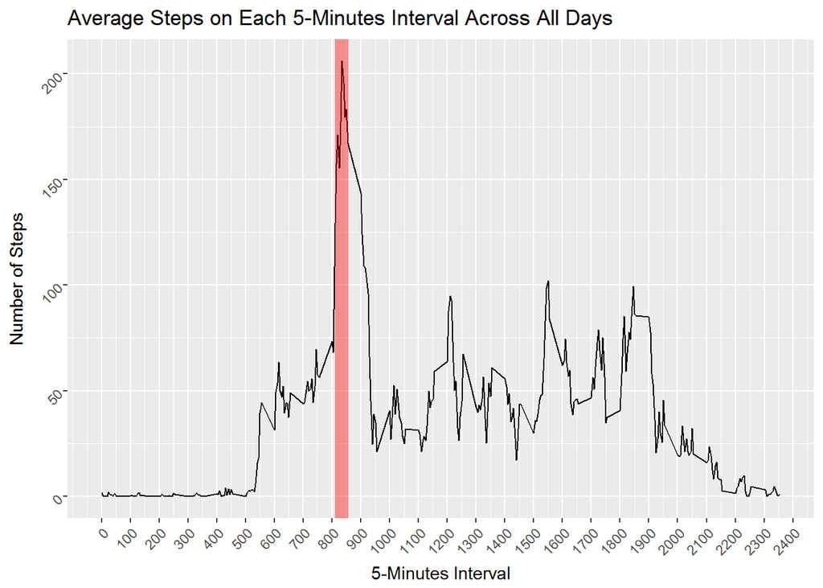

```r
actiGrouped <- group_by(activity, interval) %>%
    summarise(meanSteps = mean(steps, na.rm = T))

interval_max <- actiGrouped$interval[which.max(actiGrouped$meanSteps)]

ggplot(actiGrouped, aes(interval, meanSteps)) +
    geom_line() +
    xlab('5-Minutes Interval') +
    ylab('Number of Steps') +
    labs(title = 'Average Steps on Each 5-Minutes Interval Across All Days') +
    scale_x_continuous(breaks = pretty(actiGrouped$interval, n = 30)) +
    theme(axis.text = element_text(angle = 45, hjust = 1)) +
    geom_vline(xintercept = interval_max,
               color = 'red',
               lwd = 4,
               alpha = 0.4)
```

- Finding: As the time series plot shows, the interval, 835, indicated by the red-shaded area, contains the maximum number of steps across all days.

#### *Strategy for imputing missing values*

```r
numMissing <- nrow(filter(activity, is.na(steps)))
activitySplit <- split(activity, activity$date)

for (i in 1:61) {
    if (any(is.na(activitySplit[[i]]$steps))) {
        activitySplit[[i]] <- mutate(activitySplit[[i]], steps = actiGrouped$meanSteps)
    }
}

activityNoMissing <- do.call('rbind', activitySplit)
```

- Finding: There are 2304 missing values.
- Missing value imputing strategy: By carefully examining the missing part, I found that there were 8 full days of value appeared to be missing. I decided to impute missing values with average steps on each interval, so this way, the imputed value could have some variability.

#### *New histogram for total number of steps taken each day*

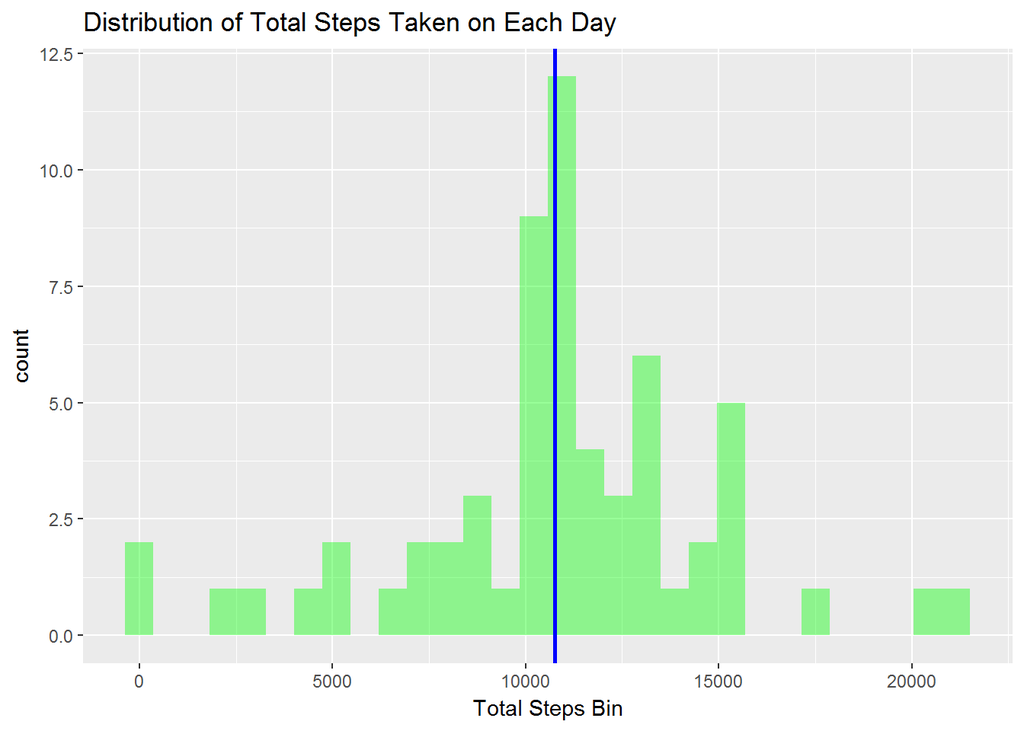

```r
actiGrouped <- group_by(activityNoMissing, date) %>%
    summarise(totalsteps = sum(steps))

meanSteps <- mean(actiGrouped$totalsteps, na.rm = T)
medianSteps <- median(actiGrouped$totalsteps, na.rm = T)

ggplot(actiGrouped, aes(actiGrouped$totalsteps)) +
    geom_histogram(fill = 'green',
                   alpha = 0.4) +
    labs(title = 'Distribution of Total Steps Taken on Each Day') +
    labs(x = 'Total Steps Bin') +
    geom_vline(xintercept = mean(actiGrouped$totalsteps, na.rm = T),
               color = 'red',
               lwd = 1) +
    geom_vline(xintercept = median(actiGrouped$totalsteps, na.rm = T),
               color = 'blue',
               lwd = 1)
```

#### *Pattern comparison between weekdays and weekends*

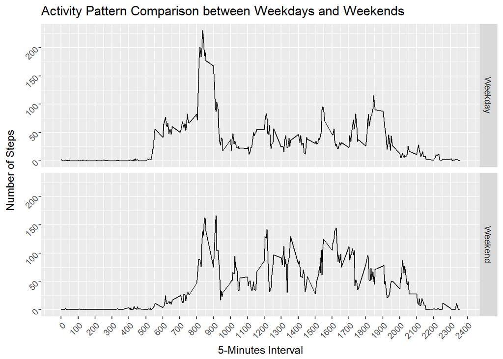

```r
actiGrouped <- mutate(activityNoMissing,
                      date = as.Date(date),
                      weekday = ifelse(weekdays(date) == 'Saturday' | weekdays(date) == 'Sunday', 'Weekend', 'Weekday')) %>%
    group_by(interval, weekday) %>%
    summarise(meanSteps = mean(steps))

ggplot(actiGrouped, aes(interval, meanSteps)) +
    geom_line() +
    xlab('5-Minutes Interval') +
    ylab('Number of Steps') +
    labs(title = 'Activity Pattern Comparison between Weekdays and Weekends') +
    scale_x_continuous(breaks = pretty(actiGrouped$interval, n = 30)) +
    theme(axis.text = element_text(angle = 45, hjust = 1)) +
    facet_grid(weekday ~.)
```